# Data Visualization Notes

### Facet to Make Small Multiples

The previous plot is very messy. One option is to *facet* the data by some third variable, making a “small multiple” plot.

A separate panel is drawn for each value of the faceting variable. Facets are not a *geom*, but a way of organising a series of *geom*s. In this case, we will use *facet_wrap()* to split the plot by *continent*. Pass *continent* as an argument with a ~.

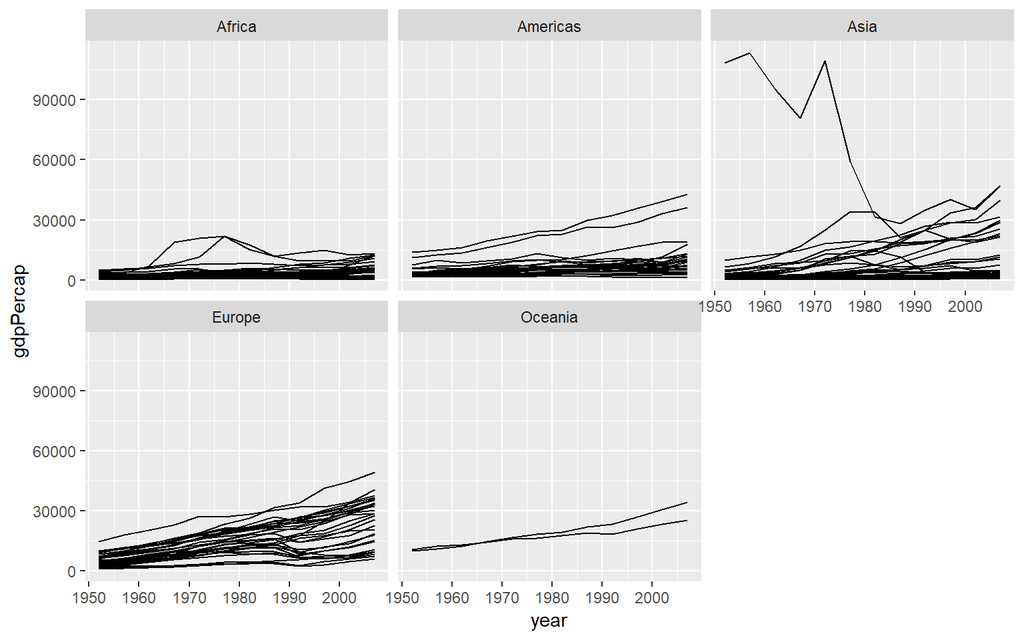

```r
p <- ggplot(data = gapminder, mapping = aes(x = year, y = gdpPercap))

p + geom_line(aes(group = country)) +

  facet_wrap(~continent)
```

We can add a smoother and some cosmetic enhancements.

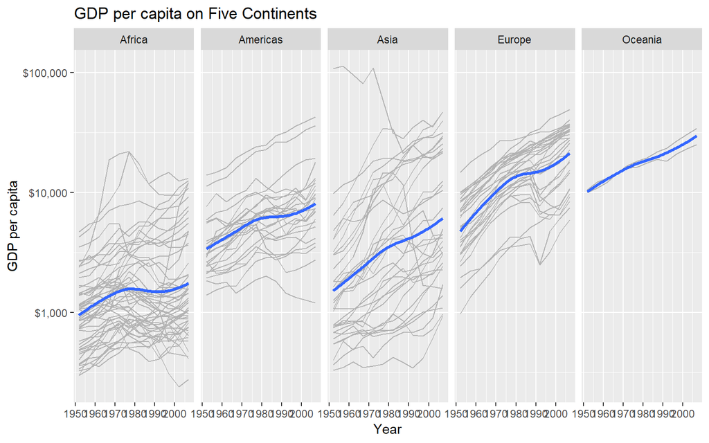

```r
p <- ggplot(data = gapminder, mapping = aes(x = year, y = gdpPercap))

p + geom_line(colour = "gray70", aes(group = country)) +

  geom_smooth(size = 1.1, method = "loess", se = FALSE) +

  scale_y_log10(labels=scales::dollar) +

  facet_wrap(~continent, ncol = 5) +

  labs(x = "Year",

       y = "GDP per capita",

       title = "GDP per capita on Five Continents")
```

Data can be cross-classified by two categorical variables by using *facet_grid()*. We will use the *gss_sm* dataset, which is a small subset of the questions from the 2016 General Social Surbey. Unlike the *gapminder* dataset, it contains many categorical variables.

We wish to make a smoothed scatterplot of the relationship between the age of the respondent (*age*) and the number of children they have (*childs*). We will facet this relationship by *sex* and *race*, using *facet_grid(sex ~ race)*:

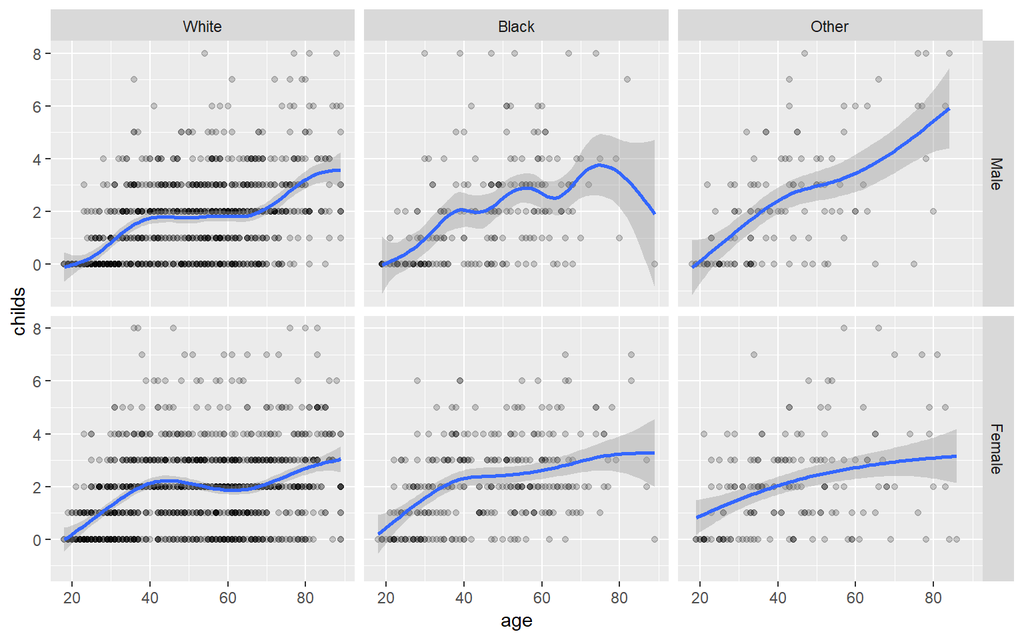

```r
p <-  ggplot(data = gss_sm,

             mapping = aes(x = age, y = childs))

p + geom_point(alpha = 0.2) +

  geom_smooth() +

  facet_grid(sex ~ race)
```

Further categorical variables can be added, such as *facet_grid(sex ~ race + degree)*, which will have a row for each *sex* variable and a column for each combination of *race* and *degree*.

### Geoms Can Transform Data

Whereas *geom_point()* just plots a point with given x and y coordinates, other *geom*s transform data before they are plotted (think of the smoother created by *geom_smooth()*).

Every *geom_* function has an associated *stat_* function and vice versa.

Sometimes the calculations done by the *stat_* functions are not immediately obvious. Consider *geom_bar()*:

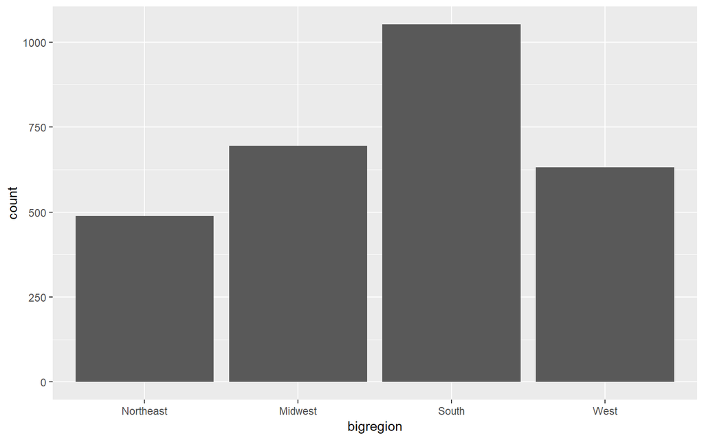

```r
p <-  ggplot(data = gss_sm, mapping = aes(x = bigregion))

p + geom_bar()
```

The bar height gives the count of observations from each region of the USA. There is a y-axis variable, called *count*, that is not in the data but has been calculated for us. Behind the scenes, *geom_bar()* calls its default *stat_* function, *stat_count()*. The function computes two new variables, *count* and *prop* (short for proportion). If we want to use *prop* in our bar chart, it must be used as a mapping. The relevant argument is *..prop..* (we need it to begin and end with two periods so that it won’t be confused if there is already a *prop* variable in our data. **Use ..statistic..**

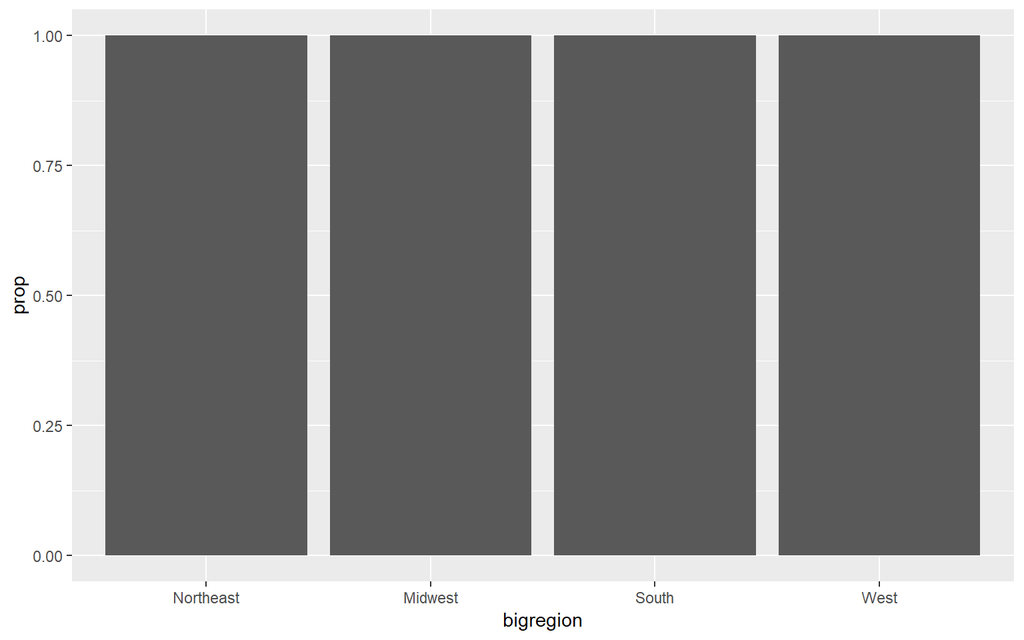

```r
p <-  ggplot(data = gss_sm, mapping = aes(x = bigregion))

p + geom_bar(mapping = aes(y = ..prop..))
```

This is not what we want. The data is being grouped by the x-categories, whereas we want the whole data to be grouped, so each bar represents the proportion of the whole data. We do this using *group = 1* inside the aes() call (1 being a “dummy group” representing the whole dataset).

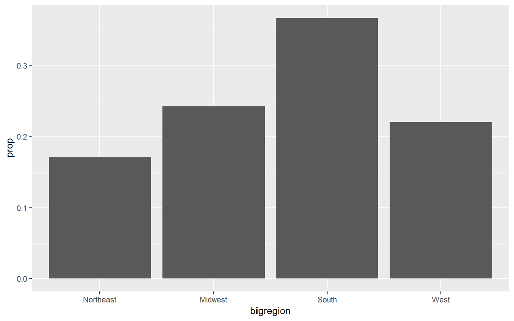

```r
p <-  ggplot(data = gss_sm, mapping = aes(x = bigregion))

p + geom_bar(mapping = aes(y = ..prop.., group = 1))
```

The *gss_sm* data contains a *religion* variable. Let’s graph this as a bar chart, with a colour for each religion:

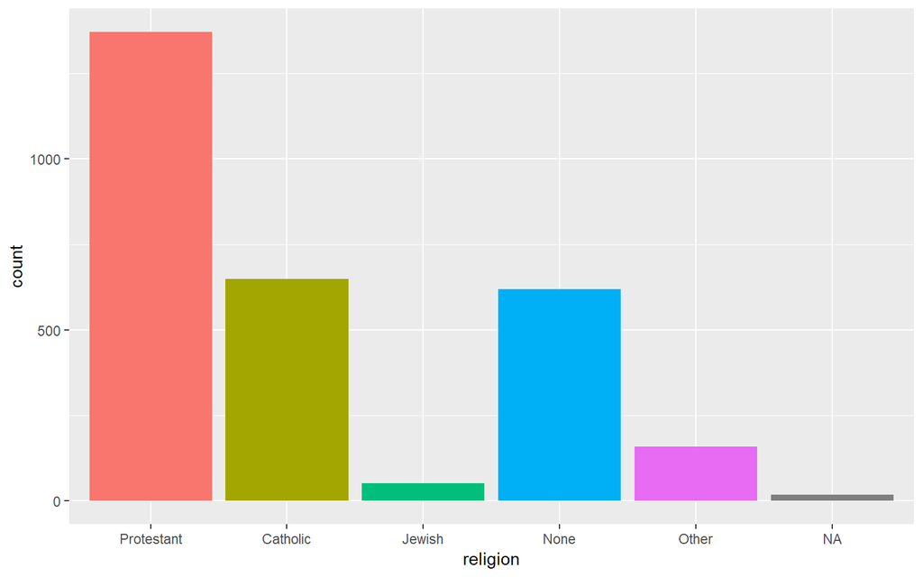

```r
p <- ggplot(data = gss_sm, mapping = aes(x = religion, fill = religion))

p + geom_bar() + guides(fill = FALSE)
```

Both *x* and *fill* are mapped to *religion*. Because we do not need a legend showing which colour represents each religion (we can read that from the x-axis), we turn off the legend using *guides(fill = FALSE)*.

### Frequency Plots the Slightly Awkward Way

A more appropriate use of the *fill* aesthetic with *geom_bar()* is to cross-classify two categorical variables. For example, to examine the distribution of religious preferences within different regions of the United States. (**Note:** This is not the most straightforward way of producing these bar charts. We will see a better way in the next chapter, where we calculate a table first).

Let’s look at the breakdown of religion by region; that is, we want the *religion* variable broken down proportionally within *bigregion*. Map *fill* to *religion*:

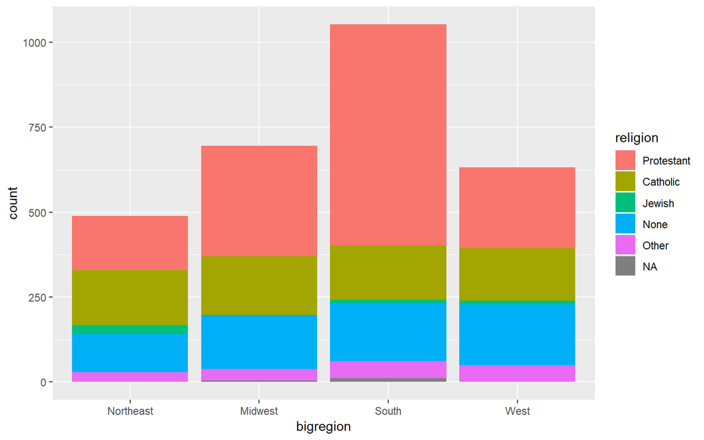

```r
p <- ggplot(data = gss_sm, mapping = aes(x = bigregion, fill = religion))

p + geom_bar()
```

This is a stacked bar chart, where the counts of each religion are stacked within each bar. A problem with this is that each religion is unaligned and so it is hard to compare the heights.

An alternative is to set the *position* argument to “fill” in the *geom_* function:

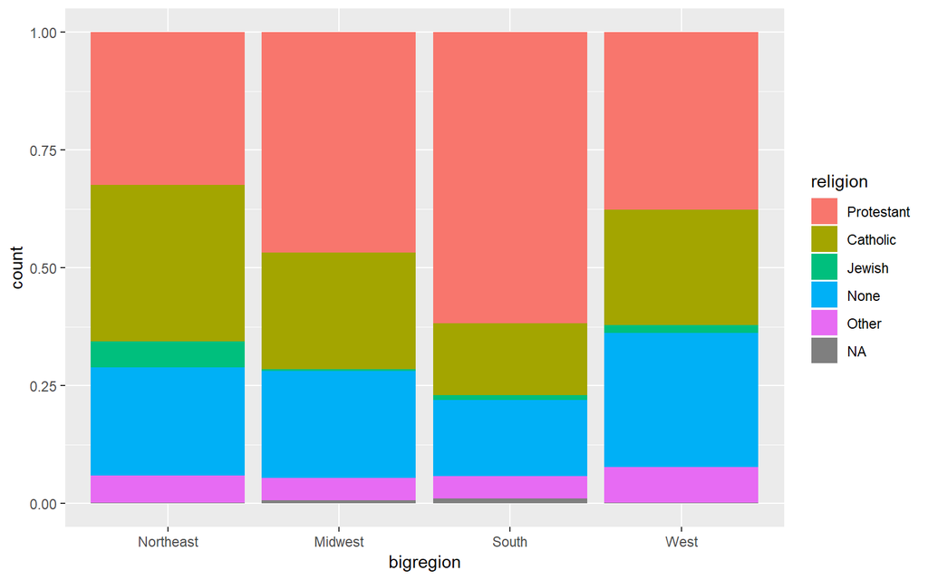

```r
p <- ggplot(data = gss_sm, mapping = aes(x = bigregion, fill = religion))

p + geom_bar(position = "fill")
```

This makes it easier to compare the proportion of each religion in a region, but we lose the relative sizes of the regions.

We could also set *position = “dodge”* to place the religions side by side in each region…

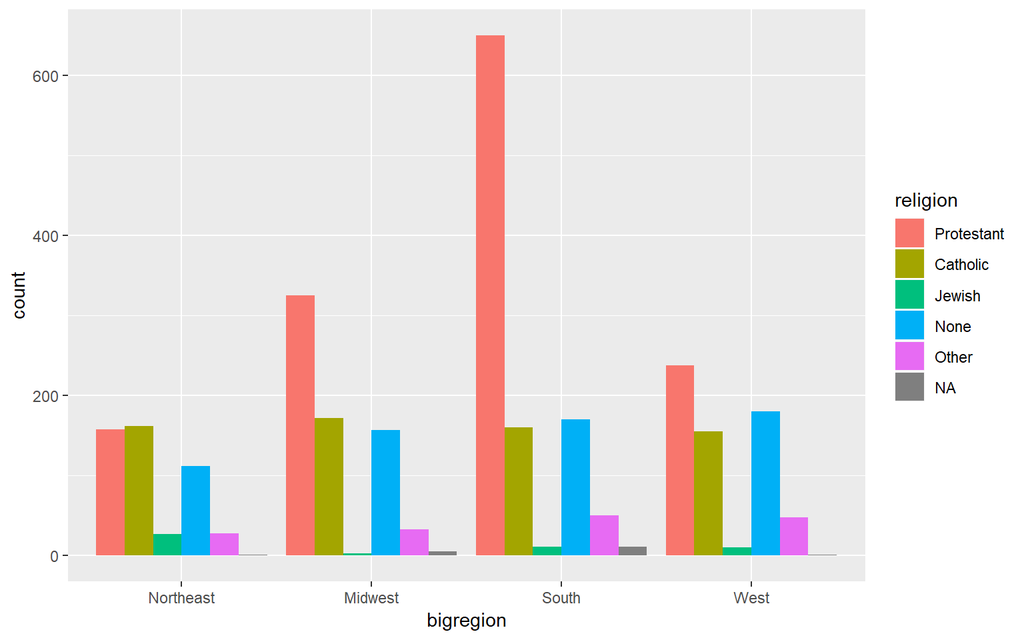

```r
p <- ggplot(data = gss_sm, mapping = aes(x = bigregion, fill = religion))

p + geom_bar(position = "dodge")
```

…but this shows counts, not proportions. We have already seen that using *y = ..prop..* can be used to use proportions…

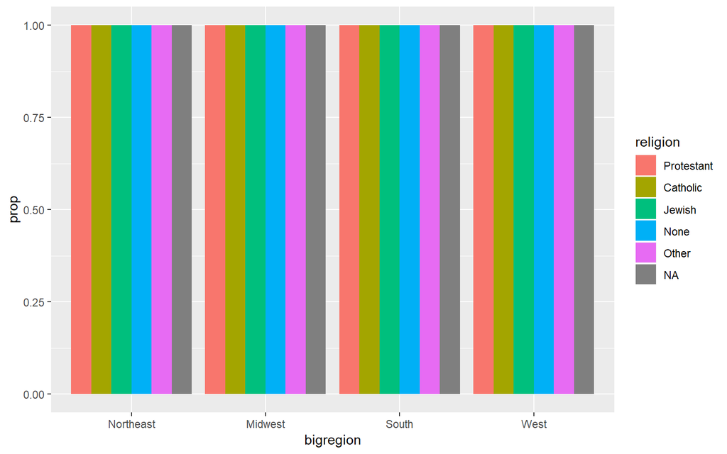

```r
p <- ggplot(data = gss_sm, mapping = aes(x = bigregion, fill = religion))

p + geom_bar(position = "dodge", mapping = aes(y = ..prop..))
```

…but this is not useful. The problem is we are seeing the proportion of Protestants that are Protestant (and Catholics are Catholic etc) in each region, which is 100% in each case. Previously we fixed this using the *group* argument. If we set *group = religion*…

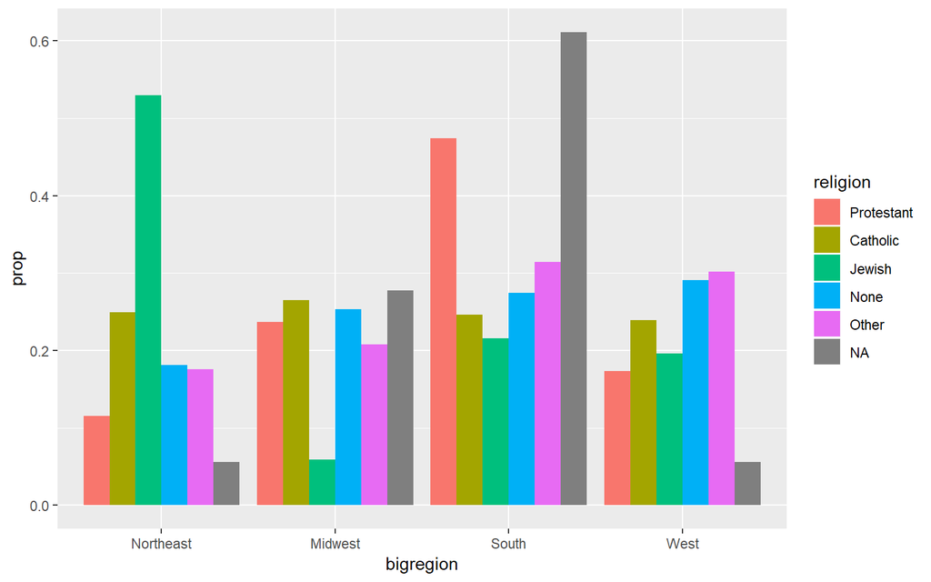

```r
p <-  ggplot(data = gss_sm, mapping = aes(x = bigregion, fill = religion))

p + geom_bar(position = "dodge", mapping = aes(y = ..prop.., group = religion))
```

…then we see what proportion of Protestants live in each region (and Catholics etc). So we see that nearly half of all Protestants live in the South. The bars for each religion sum to one across the regions, but the bars do not sum to one in each region.

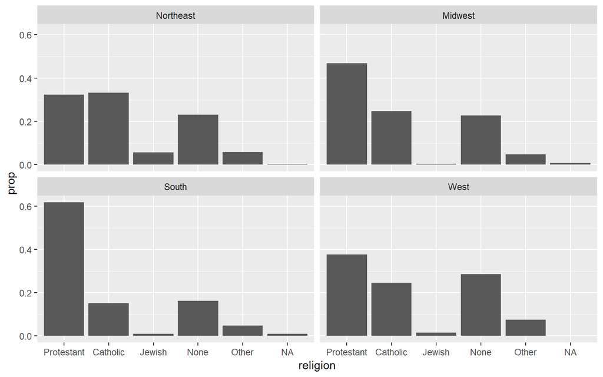

```r
p <- ggplot(data = gss_sm, mapping = aes(x = religion))

p + geom_bar(mapping = aes(y = ..prop.., group = bigregion)) + facet_wrap(~bigregion)
```

Note: in this case we group by *bigregion*, not *religion*. Otherwise we will just find that 100% of Protestants in a region are Protestant.

### Histograms and Density Plots

A histogram is a way of summarizing a continuous variable by chopping it up into segments or “bins” and counting how many observations are found within each bin. We have to decide how finely to bin the data.

The *midwest* dataset contains information on counties in several midwestern states of the United States. Counties vary in size, so we can make a histogram showing the distribution of their geographical areas (measured in square miles).

We need to divide the observations in to bins. *geom_histogram()* will choose a bin size for us based on a rule of thumb. The histogram displays a count of observations in each bin.

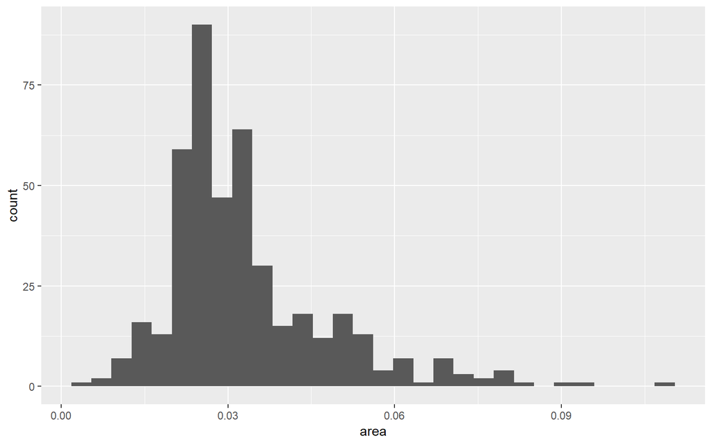

```r
p <- ggplot(data = midwest, mapping = aes(x = area))

p + geom_histogram()
```

We can set the number of bins using *bins*, or the width of each bin using *binwidth*:

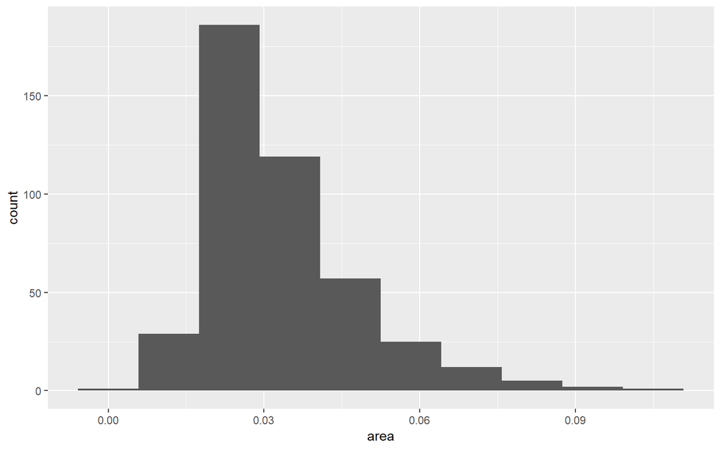

```r
p <- ggplot(data = midwest, mapping = aes(x = area))

p + geom_histogram(bins = 10)
```

As with bar charts, a newly created *count* variable is created and displayed.

We can display multiple histograms in one plot. Let’s *subset* our data so we only look at counties in two states: Ohio “OH” and Wisconsin “WI”, giving them different fills.

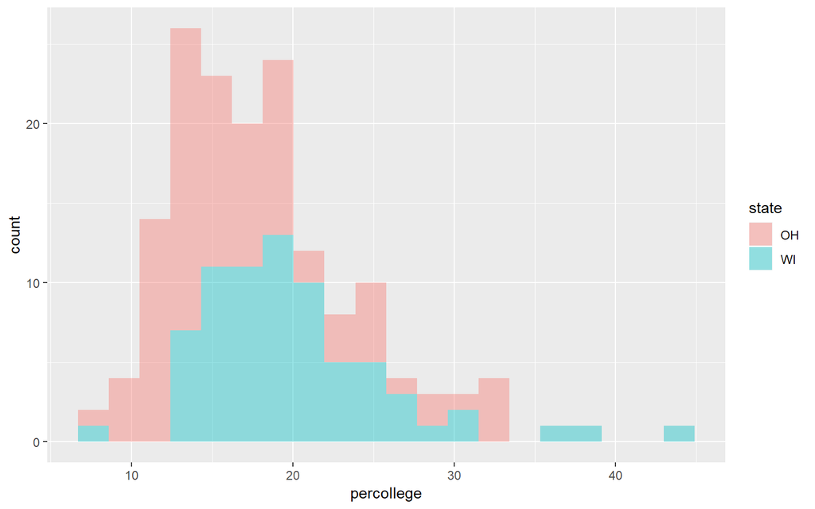

```r
oh_wi <- c("OH", "WI")

p <- ggplot(data = subset(midwest, subset = state %in% oh_wi), mapping = aes(x = percollege, fill = state))

p + geom_histogram(alpha = 0.4, bins = 20)
```

An alternative to a histogram is to calculate a kernel density estimate of the underlying distribution. The *geom_density()* function will do this:

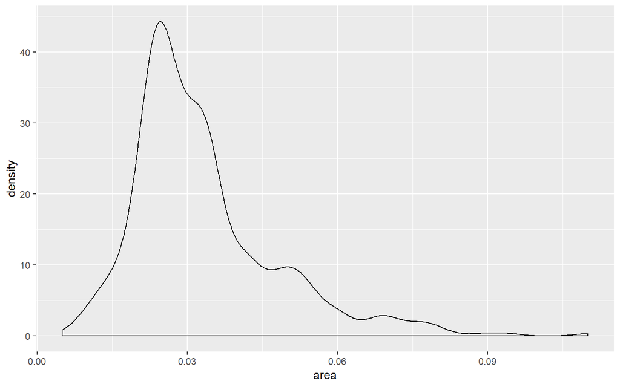

```r
p <-  ggplot(data = midwest, mapping = aes(x = area))

p + geom_density()
```

A similar plot can be achieved using *geom_line(stat = “density”)*, which removes the lines at the sides and bottom of the area (and doesn’t allow a fill):

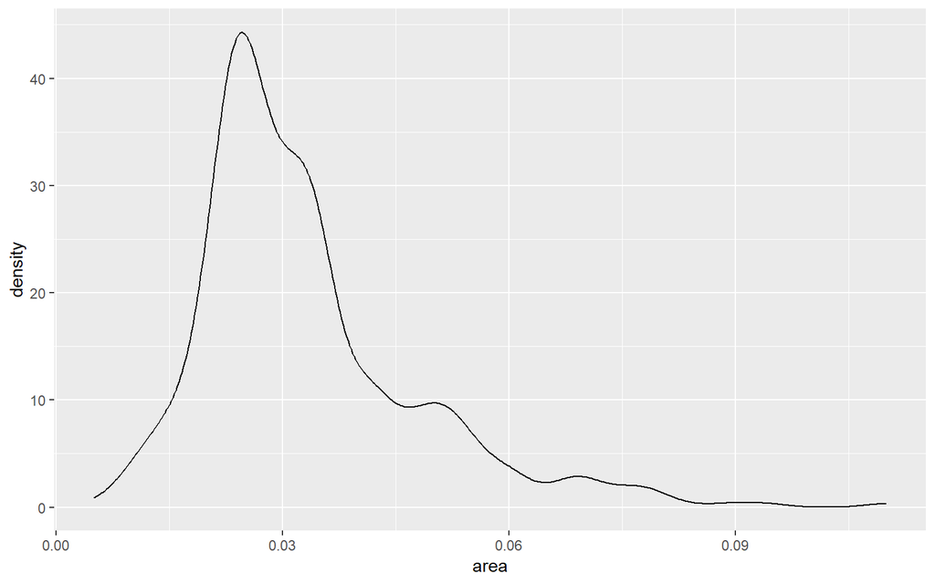

```r
p <-  ggplot(data = midwest, mapping = aes(x = area))

p + geom_line(stat = "density")
```

We can use *colour* and *fill* for *geom_density()* too. We could map each state to a different colour and fill, allowing us to see them in one plot.

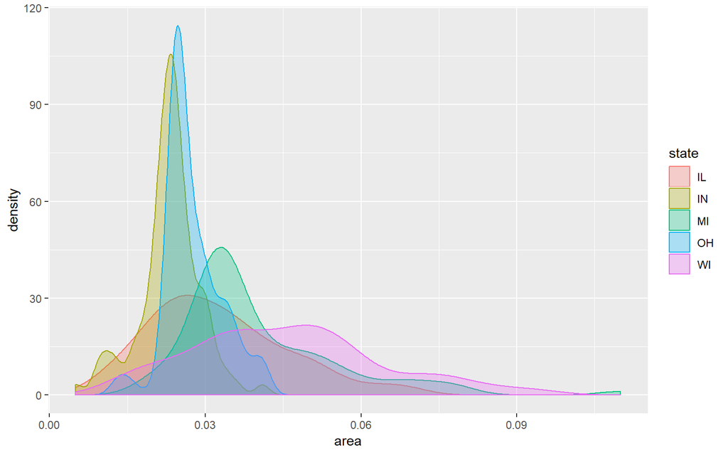

```r
p <- ggplot(data = midwest, mapping = aes(x = area, colour = state, fill = state))

p + geom_density(alpha = 0.3)
```

When using *geom_bar()*, we saw we could use the *..prop..* statistic for a proportional measure, instead of the *..count..* statistic. We can do something similar with *geom_histogram()* and *geom_density()* using their *stat_* functions.

From *geom_density()*, the *stat_density()* function can return its default *..density..* statistic, or *..scaled..*, which will give a proportional density estimate.

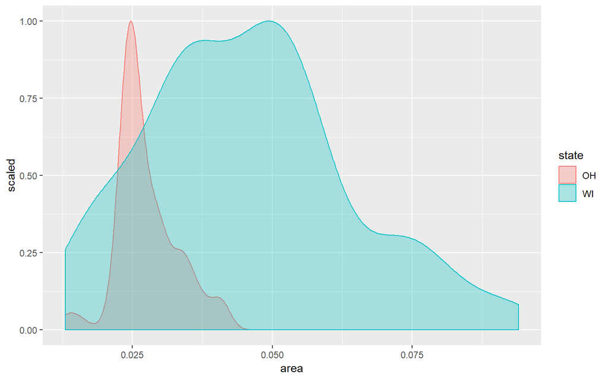

```r
p <- ggplot(data = subset(midwest, subset = state %in% oh_wi),

            mapping = aes(x = area, fill = state, colour = state))

p + geom_density(alpha = 0.3, mapping = aes(y = ..scaled..))
```

It can also return a statistic called *..count..*, which is the density times the number of points. This can be used in stacked density plots.

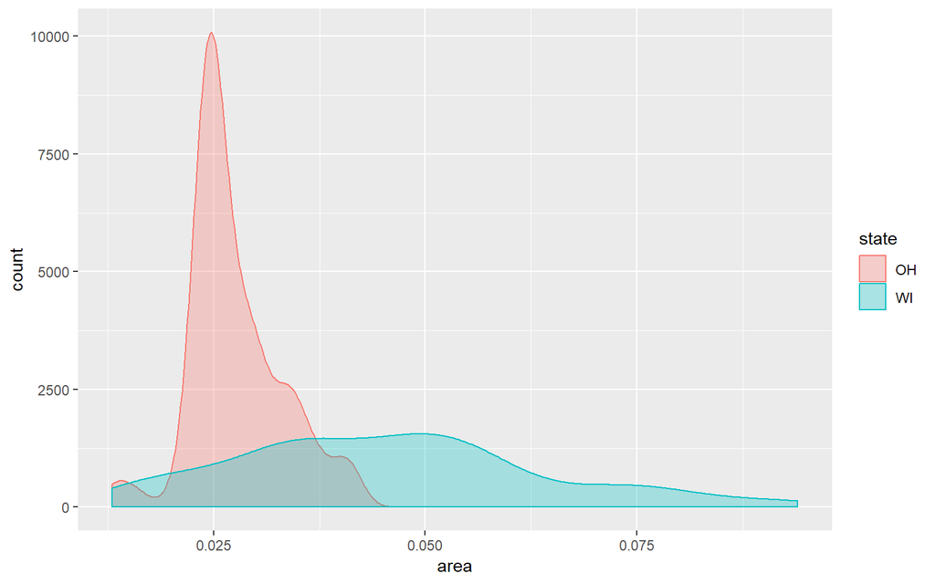

```r
p <- ggplot(data = subset(midwest, subset = state %in% oh_wi),

            mapping = aes(x = area, fill = state, colour = state))

p + geom_density(alpha = 0.3, mapping = aes(y = ..count..))
```

### Avoid Transformations When Necessary

Sometimes data will already have counts or proportions in them…

```r
titanic
```

```
##       fate    sex    n percent
## 1 perished   male 1364    62.0
## 2 perished female  126     5.7
## 3 survived   male  367    16.7
## 4 survived female  344    15.6
```

…so we do not need a *stat_* function to calculate these things for us. Use *stat = “identity”* in the *geom_* function. (We’ll also move the legend to the top of the plot):

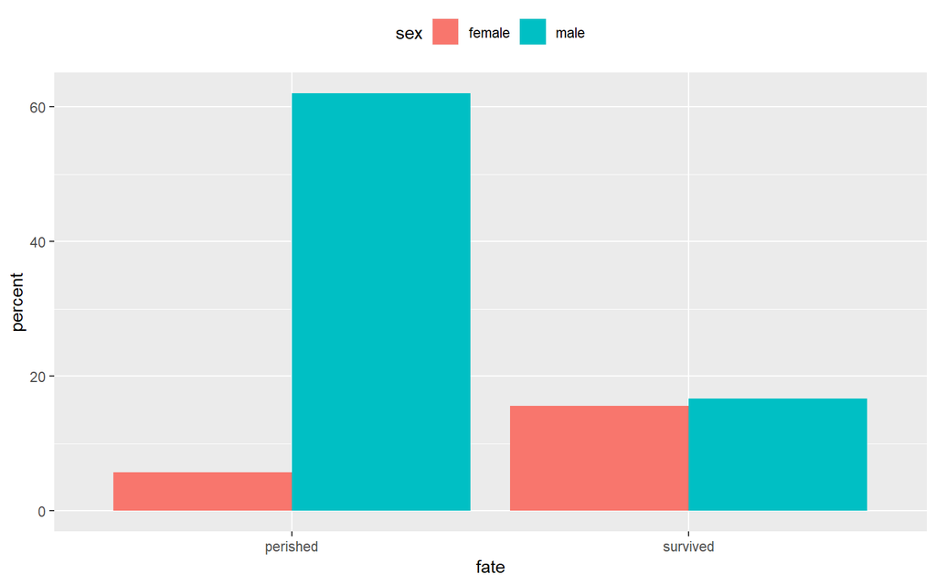

```r
p <- ggplot(data = titanic, mapping = aes(x = fate, y = percent, fill = sex))

p + geom_bar(position = "dodge", stat = "identity") + theme(legend.position = "top")
```

*geom_col()* has the same effect as using *geom_bar(stat = “identity”)*.

We can also use *position = “identity”* to plot the values as given. This lets us plot a flow of positive and negative values in a bar chart. This is useful when looking at changes to some threshold level or baseline. The *oecd_sum* table in *socviz* contains information on average life expectancy at birth within the USA and other OECD countries.

```r
oecd_sum
```

```
## # A tibble: 57 x 5
## # Groups:   year [57]
##     year other   usa  diff hi_lo
##    <int> <dbl> <dbl> <dbl> <chr>
##  1  1960  68.6  69.9 1.3   Below
##  2  1961  69.2  70.4 1.2   Below
##  3  1962  68.9  70.2 1.30  Below
##  4  1963  69.1  70   0.9   Below
##  5  1964  69.5  70.3 0.800 Below
##  6  1965  69.6  70.3 0.7   Below
##  7  1966  69.9  70.3 0.400 Below
##  8  1967  70.1  70.7 0.6   Below
##  9  1968  70.1  70.4 0.3   Below
## 10  1969  70.1  70.6 0.5   Below
## # ... with 47 more rows
```

The *other* column is the average life expectancy in a given year for countries *excluding* the United States. The *usa* column is the U.S. life expectancy. *diff* is the difference between the two values, and *hi_lo* indicates whether the U.S. value is higher or lower than the OECD average.

We will plot the difference over time and use the *hi_lo* variable to colour the columns in the chart.

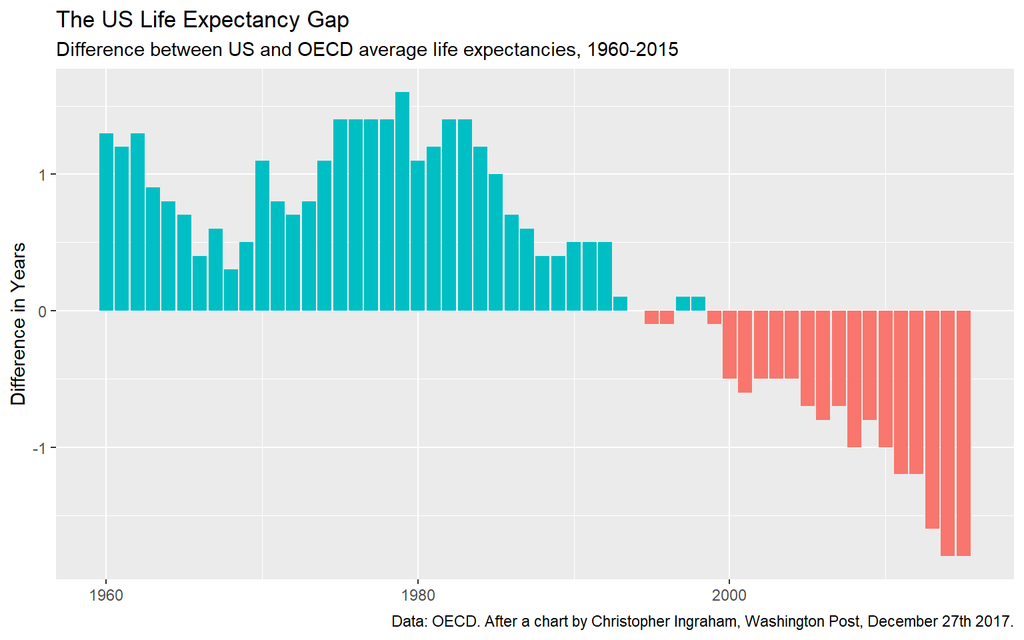

```r
p <- ggplot(data = oecd_sum, mapping = aes(x = year, y = diff, fill = hi_lo))

p + geom_col() + guides(fill = FALSE) +

  labs(x = NULL, y = "Difference in Years",
       title = "The US Life Expectancy Gap",
       subtitle = "Difference between US and OECD average life expectancies, 1960-2015",
       caption = "Data: OECD. After a chart by Christopher Ingraham, Washington Post, December 27th 2017.")
```

## Graph Tables, Make Labels, Add Notes